# Investigating Population Health and Economic Consequences of Weather Events in the United States

Thomas R Nudell

January 4, 2017

```r
library(dplyr)
```

```r
library(tidyr)
library(stringr)
library(ggplot2)
```

```r
setwd("/home/trn/Dropbox/xxX/xxR/RRR/RepData_PeerAssignment2")
```

## Summary

This data analysis addresses the two following questions:

1. Across the United States, which types of events (as indicated in the `EVTYPE` variable) are most harmful with respect to population health?
2. Across the United States, which types of events have the greatest economic consequences?

## Data Processing

The data we will analize is a National Oceanic and Atmospheric Administration (NOAA) storm database. This data comes in the form of a comma seperated value (csv) file compressed with the bzip2 (bz2) algorithm. We will name data file `StormData.csv.bz2`.

```r
f.data <- "StormData.csv.bz2"
```

If the data doesn’t already exists in the same directory as this script, we will need to download it from the course website.

```r
if (!file.exists(f.data)) {
  f.url <- "https://d396qusza40orc.cloudfront.net/repdata%2Fdata%2FStormData.csv.bz2"
  download.file(f.url,f.data, method="curl")
}
```

We next read the data into memory.

```r
df <- read.csv(f.data)
```

### Preprocessing

Our data set contains information about 985 different types of events, listed in the `EVTYPE` variable, which can be seen by taking a peak at the unique entries.

```r
print(unique(df$EVTYPE))
```

```
##   [1] TORNADO                        TSTM WIND
##   [3] HAIL                           FREEZING RAIN
##   [5] SNOW                           ICE STORM/FLASH FLOOD
##   [7] SNOW/ICE                       WINTER STORM
##   [9] HURRICANE OPAL/HIGH WINDS      THUNDERSTORM WINDS
##  [11] RECORD COLD                    HURRICANE ERIN
##  [13] HURRICANE OPAL                 HEAVY RAIN
##  [15] LIGHTNING                      THUNDERSTORM WIND
##  [17] DENSE FOG                      RIP CURRENT
##  [19] THUNDERSTORM WINS              FLASH FLOOD
##  [21] FLASH FLOODING                 HIGH WINDS
##  [23] FUNNEL CLOUD                   TORNADO F0
##  [25] THUNDERSTORM WINDS LIGHTNING   THUNDERSTORM WINDS/HAIL
##  [27] HEAT                           WIND
##  [29] LIGHTING                       HEAVY RAINS
```

[output cut: 479 more lines]

Looking at these unique entries also raises some questions about the cleanliness of this data. For example, `TSTM WIND` represents the same thing as `THUNDERSTORM WIND` which is the same as `THUNDERSTORM WINDS`, etc. In summary, our data is not clean and not tidy. However, because this project is not designed to test how well one can clean and tidy data, so I’ll just walk through a few quick proceedures to tidy things up a bit.

The documentation for this data, [Storm Data Documentation](https://d396qusza40orc.cloudfront.net/repdata%2Fpeer2_doc%2Fpd01016005curr.pdf) only lists 48 different event types (see Table 1 on Page 6). I couldn’t find a tablular form of this data so I copy/pasted Table 1 into a text file `EVTYPE.txt` and read it in using `read.delim` specifying a new line as the deliminator.

```r
EVTYPE <- read.delim('EVTYPE.txt', header=FALSE, sep = "\n")
```

The are “[C/Z/M]” characters at the end of the string that indicate what type of region the event was recorded in. Eventually it would be nice to give them their own column in our table. First we just extract the event types out.

```r
EVTYPE <- separate(EVTYPE,V1, into = "NAMES", sep="[C,Z,M]$")
EVTYPE$NAMES <- str_trim(EVTYPE$NAMES, side="both")
```

Next we do some convert the coded names to the closest true `EVTYPE`. If you know of a better way to do this, please let me know; I’m eager to learn. This first function will take an input string and return the closest element in `EVTYPE$NAMES`. It requires the `stringdist` package.

```r
library("stringdist")
evtypeMatch <- function(X){
  as.character(EVTYPE$NAMES[which.min(stringdist(toupper(X),toupper(EVTYPE$NAMES)))])
}

df <- mutate(df,EVTYPE = sapply(df$EVTYPE,evtypeMatch))
```

Next, we note that the values in `PROPDMG` and `CROPDMG` need to be adjusted by orders of magnitude according the entries in `PROPDMPEXP` and `CROPDMPEXP` repsectively. The valid values are “K” for thousands, “M” for millions, and “B” for billions. We will add a new variable which maps the alphabetical code to a numerical magnitude, then mutate the variables.

```r
magnitude <- data.frame(ALPHA=c("K", "M","B"), MAG=c(1e3,1e6,1e9))
```

```r
df <- df %>%
       mutate(CROPDMGEXP=toupper(CROPDMGEXP)) %>%
       mutate(PROPDMGEXP=toupper(PROPDMGEXP))

df <- left_join(x=df,y=magnitude,by=c('CROPDMGEXP'='ALPHA')) %>%
        mutate(CROPDMG=CROPDMG*MAG.y) %>%
        select(-MAG.y) %>%
        left_join(x=df,y=magnitude,by=c('PROPDMGEXP'='ALPHA')) %>%
        mutate(PROPDMG=PROPDMG*MAG.y) %>%
        select(-MAG.y)
```

## Results

### Population Health

We will measure population health impacts as the total number of `INJURIES` plus the total number of `FATALITIES` for a given event. TO clean things up a bit, we create a new dataframe with summarization of `INJURIES` plus `FATALITIES` by `EVTYPE`.

```r
health_df <- df %>%
             select(EVTYPE,INJURIES,FATALITIES) %>%
             mutate(HEALTH_IMPACT = INJURIES + FATALITIES) %>%
             group_by(EVTYPE) %>%
             summarize(TOTAL_HEALTH = sum(HEALTH_IMPACT))
```

The first thing to notice is that most events have no health impact, so in order to get a better picture of impactful events, we filter out all event types with no health impacts.

```r
health_df <- filter(health_df, TOTAL_HEALTH != 0)
```

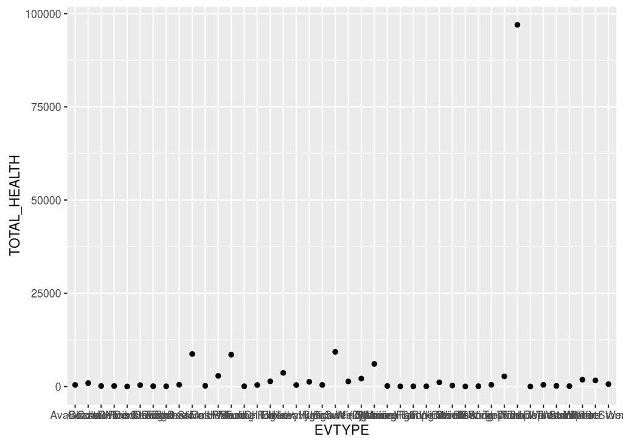

```r
g.health <- ggplot(health_df, aes(x=EVTYPE, y=TOTAL_HEALTH))
g.health + geom_point()
```

We can see in the plot that one event type has far and away the largest health impact, and that event type is “Tornado”.

```r
print(health_df$EVTYPE[which.max(health_df$TOTAL_HEALTH)])
```

```
## [1] "Tornado"
```

### Economic Consequences

We measure economic consequences as the sum of property damage (`PROPDMG`), crop damage (`CROPDMG`). Since we were not able to determine the magnitude of a number of entries we will have to remove the NA values as well.

```r
econ_df <- df %>%
           select(EVTYPE,PROPDMG,CROPDMG) %>%
           mutate(DMG = PROPDMG+CROPDMG) %>%
           group_by(EVTYPE) %>%
           summarize(TOTAL_DMG = sum(DMG, na.rm=TRUE ))

head(econ_df)
```

```
## # A tibble: 6 × 2
##                  EVTYPE TOTAL_DMG
##                   <chr>     <dbl>
## 1 Astronomical Low Tide   9745000
## 2             Avalanche   3721800
## 3              Blizzard 659334122
## 4         Coastal Flood 520276679
## 5       Cold/Wind Chill   2315100
## 6           Debris Flow  56050000
```

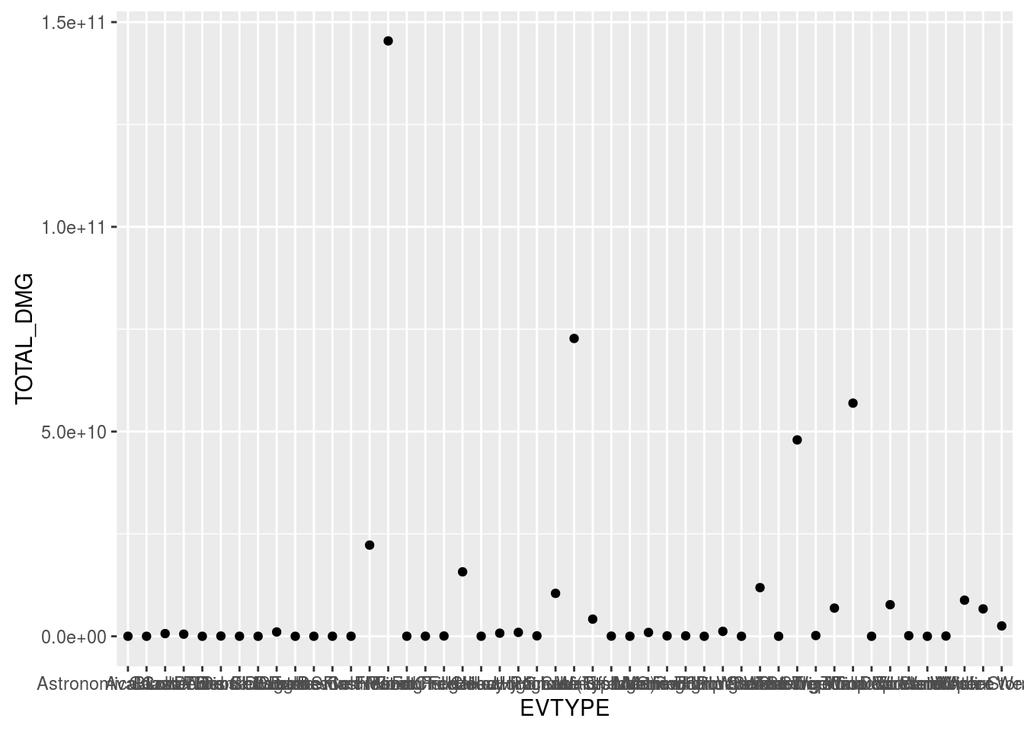

```r
g.econ <- ggplot(econ_df, aes(x = EVTYPE, y=TOTAL_DMG, rm.na=TRUE ))
g.econ + geom_point()
```

```r
print(health_df$EVTYPE[which.max(econ_df$TOTAL_DMG)])
```

```
## [1] "Funnel Cloud"
```

There is a lot more we could do with this data, but that’s it for now.